# IODS course project

## Testing hypothesis

Four hypothesis related to the alcohol consumption and the chosen variables:  
**H1**: Students who study longer during the week, consume less alcohol compared to those who study less.  
**H2**: Those students who have more free time after school consume higher amounts of alcohol than those who have less free time.  
**H3**: Those who have better family relationships consume less alcohol than those in poor family relationships.  
**H4**: Younger students consume more alcohol than older students.

```r
library(ggplot2)
library(dplyr)
```

### First hypothesis

The relationship between alcohol consumption and weekly study time will be analysed.

In the survey students had to choose how many hours a week they study. The options were:  
1 - less than 2 hours  
2 - from 2 to 5 hours  
3 - from 5 to 10 hours  
4 - more than 10 hours

Here we see that on average students study from 2 to 5 hours, because the mean of the answers is around 2 which is attributed to 2-10 hours as explained above. In addition to that, all the answers were ranging from 1 and 4.

```r
summary(alc$studytime)
```

```
##    Min. 1st Qu.  Median    Mean 3rd Qu.    Max.
##   1.000   1.000   2.000   2.037   2.000   4.000
```

To visualize the data a boxplot will be drawn.

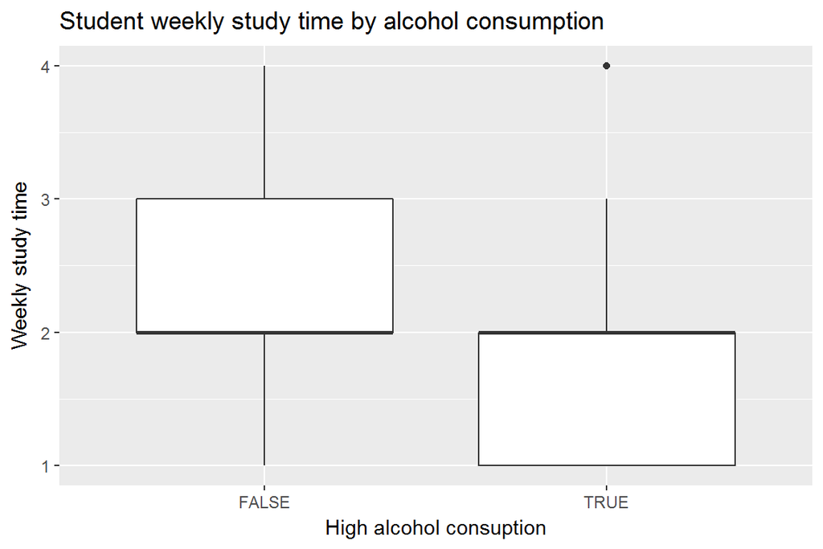

```r
g1 <- ggplot(alc, aes(x = high_use, y= studytime))
g1 + geom_boxplot(aes()) + xlab("High alcohol consuption") + ylab("Weekly study time") + ggtitle("Student weekly study time by alcohol consumption")
```

The table below shows the frequencies. It is clear that most of the students (195) study from 2 to 5 hours a week, while least students study more than 10 hours. Additionally, overall most students do not consume high amounts of alcohol weekly irrespectivelly of how much they study. However, it is obvious that students that study less than 2 hours a week have a higher proportion of students that consume more alcohol compared to all the other students.

```r
table_studytime <- xtabs(~high_use+studytime, data=alc)
ftable(table_studytime)
```

```
##          studytime   1   2   3   4
## high_use
## FALSE               58 135  52  23
## TRUE                42  60   8   4
```

Similar results are visible in the grapgh below.

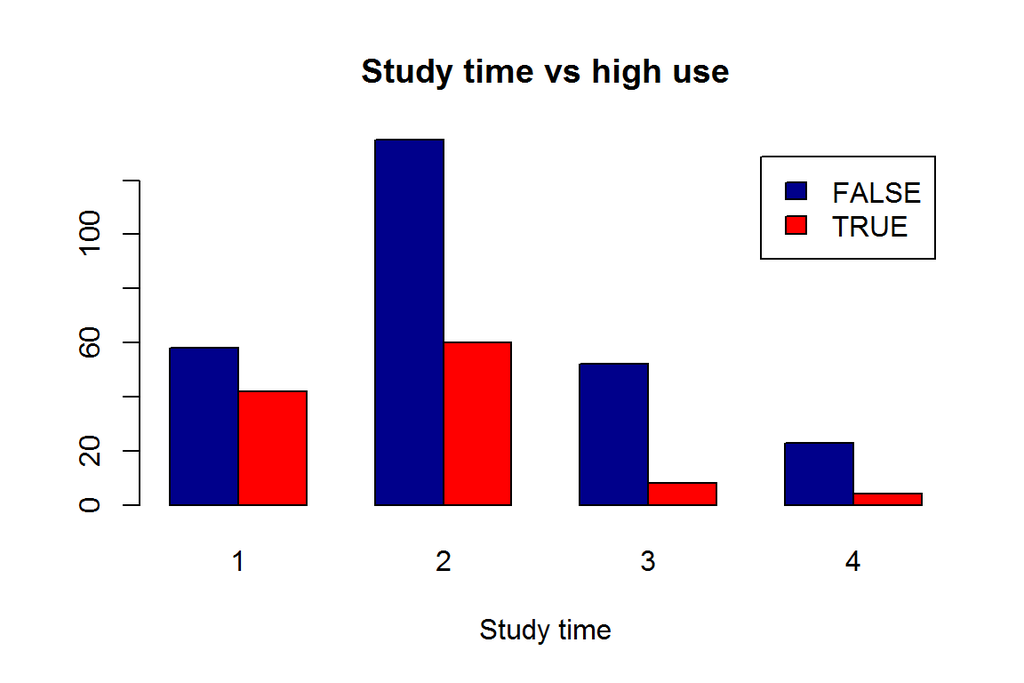

```r
counts_studytime <- table(alc$high_use, alc$studytime)
barplot(counts_studytime, main="Study time vs high use",
  xlab="Study time", col=c("darkblue","red"),
    legend = rownames(counts_studytime), beside=TRUE)
```

**H1**: Students who study longer during the week, consume less alcohol compared to those who study less.

**H1 is confimed.**

### Second Hypothesis

The relationship between alcohol consumption and amount of free time after school will be analysed.

In the survey students had to choose how much free time after school they have. The possible answers ranged from 1 - very low to 5 - very high.

We can see from the summary below that on average students chose answer 3, which is average amount of free time after school. However, all answers in the range were selected.

```r
summary(alc$freetime)
```

```
##    Min. 1st Qu.  Median    Mean 3rd Qu.    Max.
##    1.00    3.00    3.00    3.22    4.00    5.00
```

The box plot indicates that 50% of students who consume high amounts of alcohol and 50% of students who don’t had the same amount of free time (from average to high).

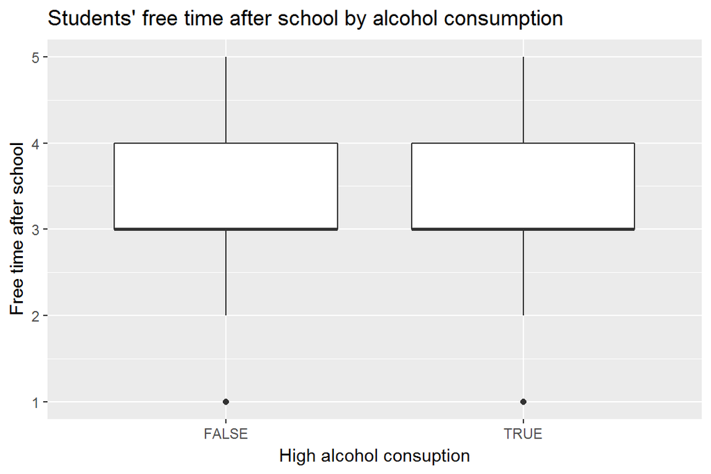

```r
g4 <- ggplot(alc, aes(x = high_use, y= freetime))
g4 + geom_boxplot(aes()) + xlab("High alcohol consuption") + ylab("Free time after school") + ggtitle("Students' free time after school by alcohol consumption")
```

**H2**: Those students who have more free time after school consume higher amounts of alcohol than those who have less free time.

### Third hypothesis

The relationship between alcohol consumption and quality of their family relationship will be analysed.

In the survey students had to choose wheather what is the quality of their family relationship. The possible answer options ranged from 1 - very bad to 5 - excellent.

On average students indicated that their relationship with the family are good (3.937), however, the whole range of answers was used in answering this question.

```r
summary(alc$famrel)
```

```
##    Min. 1st Qu.  Median    Mean 3rd Qu.    Max.
##   1.000   4.000   4.000   3.937   5.000   5.000
```

Frequencies table also shows that most of the students are in a good relationship with their family. Only 8 students indicated that the relationship was very poor.

```r
table_famrel <- xtabs(~high_use+famrel, data=alc)
ftable(table_famrel)
```

```
##          famrel   1   2   3   4   5
## high_use
## FALSE             6  10  39 135  78
## TRUE              2   9  25  54  24
```

The box plot shows that 50% of students who do not consume high amounts of alcohol have good or excellent relationships with their family, whereas, 50% of students who consume high amounts of alcohol have average or good relationships. Another interesting thing is that among the students who do not consume high amounts of alcohol the answers ranged from average to excellent, which outliers for 2 other options. In contast, the answers among the students who consume high amounts of alcohol, the answers ranged from poor to excellent, with an outlier in very poor. Thus, it can be stated that overall students who do not consume high amounts of alcohol are more in better relationships with their families.

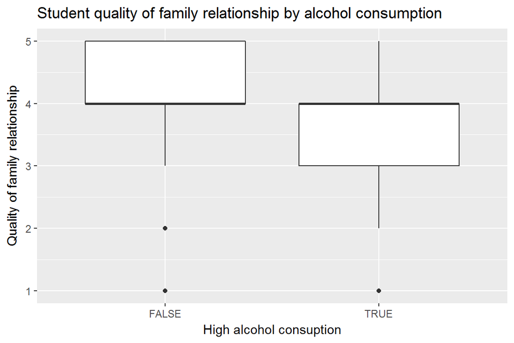

```r
g2 <- ggplot(alc, aes(x = high_use, y= famrel))
g2 + geom_boxplot(aes()) + xlab("High alcohol consuption") + ylab("Quality of family relationship") + ggtitle("Student quality of family relationship by alcohol consumption")
```

**H3**: Those who have better family relationships consume less alcohol than those in poor family relationships.

**H3 is confirmed.**

### Fourth hypothesis

The relationship between students’ alcohol consumption and their age will be analysed.

In the survey students had to indicate their actual age.

The students’ age ranged from 15 to 22 with average age of around 17.

```r
summary(alc$age)
```

```
##    Min. 1st Qu.  Median    Mean 3rd Qu.    Max.
##   15.00   16.00   17.00   16.59   17.00   22.00
```

The boxplot shows that 50% of students who do not consume high amounts of alcohol are between the age of 16 and 17, while 50% of students who consume higher amounts of alcohol are between the ages of 16 and 18 and their overall answer range is wider.

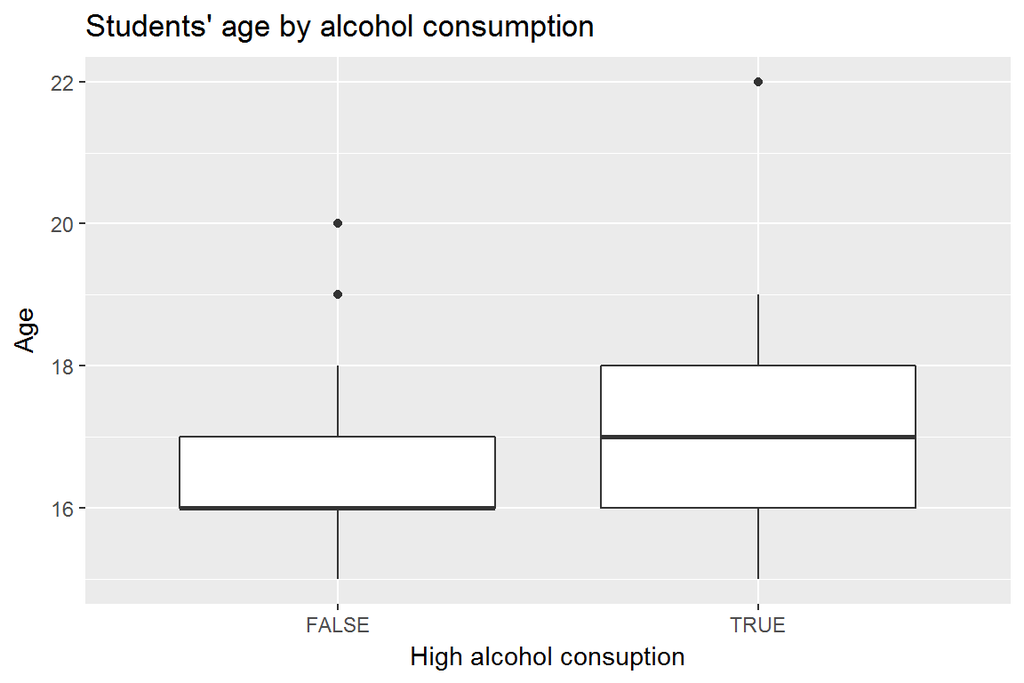

```r
g3 <- ggplot(alc, aes(x = high_use, y= age))
g3 + geom_boxplot(aes()) + xlab("High alcohol consuption") + ylab("Age") + ggtitle("Students' age by alcohol consumption")
```

**H4**: Younger students consume more alcohol than older students.

**H4 is declined.**

## Logistic regression model

A logistic regression will be used to statistically explore the four variables (*studytime, freetime, famrel, age*) and their relationship with the high/low alcohol consumption variable as the target variable.

```r
m <- glm(high_use ~ studytime + freetime + famrel + age, data = alc, family = "binomial")

summary(m)
```

```
##
## Call:
## glm(formula = high_use ~ studytime + freetime + famrel + age,
##     family = "binomial", data = alc)
##
## Deviance Residuals:
##     Min       1Q   Median       3Q      Max
## -1.7096  -0.8475  -0.6420   1.1883   2.1913
##
## Coefficients:
##             Estimate Std. Error z value Pr(>|z|)
## (Intercept)  -3.5585     1.7969  -1.980 0.047660 *
## studytime    -0.5548     0.1562  -3.551 0.000383 ***
## freetime      0.3498     0.1238   2.824 0.004736 **
## famrel       -0.3291     0.1299  -2.535 0.011253 *
## age           0.2356     0.1012   2.327 0.019949 *
## ---
## Signif. codes:  0 '***' 0.001 '**' 0.01 '*' 0.05 '.' 0.1 ' ' 1
##
## (Dispersion parameter for binomial family taken to be 1)
##
##     Null deviance: 465.68  on 381  degrees of freedom
## Residual deviance: 430.57  on 377  degrees of freedom
## AIC: 440.57
##
## Number of Fisher Scoring iterations: 4
```

```r
#chi sq
qchisq(0.95, 377)
```

```
## [1] 423.2743
```

The coeficients here mean that:  
If the value of studytime increases by one the model predicts that the log of the odds decreases by 0.55.  
If the value of freetime increases by one the model predicts that the log of the odds increases by 0.35.  
If the value of famrel increases by one the model predicts that the log of the odds decreases by 0.33.  
If the value of age increases by one the model predicts that the log of the odds increases by 0.24.

```r
coef(m)
```

```
## (Intercept)   studytime    freetime      famrel         age
##  -3.5585146  -0.5547942   0.3497904  -0.3291428   0.2355955
```

Odds ratios for freetime and age are higher than one thus it means they are positivelly associated with high use of alcohol.  
Whereas odd rations for studytime and famrel are lower than 1 so they can’t be positivelly associated with higher alcohol consumption.

```r
OR <- coef(m) %>% exp
CI <- confint(m) %>% exp
cbind(OR, CI)
```

```
##                    OR        2.5 %    97.5 %
## (Intercept) 0.0284811 0.0008002383 0.9372941
## studytime   0.5741904 0.4186785377 0.7735687
## freetime    1.4187702 1.1166313749 1.8164964
## famrel      0.7195403 0.5566658883 0.9276797
## age         1.2656622 1.0401492065 1.5488002
```

## Predictive Power of the Model

```r
probabilities <- predict(m, type = "response")
alc <- mutate(alc, probability = probabilities)
alc <- mutate(alc, prediction = probability > 0.5)
table(high_use = alc$high_use, prediction = alc$prediction)
```

```
##         prediction
## high_use FALSE TRUE
##    FALSE   249   19
##    TRUE     99   15
```

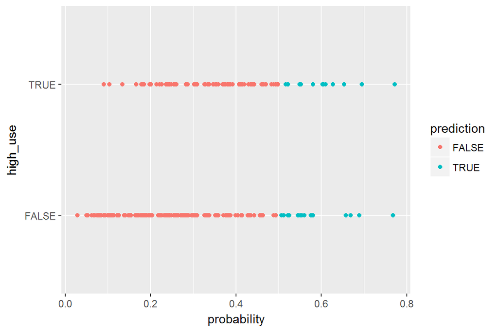

```r
gprob <- ggplot(alc, aes(x = probability, y = high_use, col = prediction))
gprob + geom_point()
```

```r
table(high_use = alc$high_use, prediction = alc$prediction) %>% prop.table() %>% addmargins()
```

```
##         prediction
## high_use      FALSE       TRUE        Sum
##    FALSE 0.65183246 0.04973822 0.70157068
##    TRUE  0.25916230 0.03926702 0.29842932
##    Sum   0.91099476 0.08900524 1.00000000
```

The average number of wrong predictions in the (training) data is 0.31.

```r
loss_func <- function(class, prob) {
  n_wrong <- abs(class - prob) > 0.5
  mean(n_wrong)
}
loss_func(class = alc$high_use, prob = alc$probability)
```

```
## [1] 0.3089005
```

The 10-fold cross-validation on the model has a higher prediction error compared to DataCamp exercise.

```r
library(boot)
cv <- cv.glm(data = alc, cost = loss_func, glmfit = m, K = 10)
cv$delta[1]
```

```
## [1] 0.3193717
```

# Clustering and Classification

## The Data

```r
library(MASS)
library(dplyr)
library('corrplot')
data("Boston")
```

The data used in this chapter describes housing values in suburbs of Boston. It has 506 observations and 14 variables.

```r
dim(Boston)
```

```
## [1] 506  14
```

The variables are listed below. Variable *crim* is per capita crime rate by town, while *ptration* is pupil-teacher ratio by town. Other variables are briefly described here: https://stat.ethz.ch/R-manual/R-devel/library/MASS/html/Boston.html

```r
str(Boston)
```

```
## 'data.frame':    506 obs. of  14 variables:
##  $ crim   : num  0.00632 0.02731 0.02729 0.03237 0.06905 ...
##  $ zn     : num  18 0 0 0 0 0 12.5 12.5 12.5 12.5 ...
##  $ indus  : num  2.31 7.07 7.07 2.18 2.18 2.18 7.87 7.87 7.87 7.87 ...
##  $ chas   : int  0 0 0 0 0 0 0 0 0 0 ...
##  $ nox    : num  0.538 0.469 0.469 0.458 0.458 0.458 0.524 0.524 0.524 0.524 ...
##  $ rm     : num  6.58 6.42 7.18 7 7.15 ...
##  $ age    : num  65.2 78.9 61.1 45.8 54.2 58.7 66.6 96.1 100 85.9 ...
##  $ dis    : num  4.09 4.97 4.97 6.06 6.06 ...
##  $ rad    : int  1 2 2 3 3 3 5 5 5 5 ...
##  $ tax    : num  296 242 242 222 222 222 311 311 311 311 ...
##  $ ptratio: num  15.3 17.8 17.8 18.7 18.7 18.7 15.2 15.2 15.2 15.2 ...
##  $ black  : num  397 397 393 395 397 ...
##  $ lstat  : num  4.98 9.14 4.03 2.94 5.33 ...
##  $ medv   : num  24 21.6 34.7 33.4 36.2 28.7 22.9 27.1 16.5 18.9 ...
```

## Correlation

From the Pairs matrix it can be seen that some of the variables are strongly correlated between each other, e.g. variables *nox* and *dis* or *lstat* and *medv*. Only a few variables seem to have normal distribution.

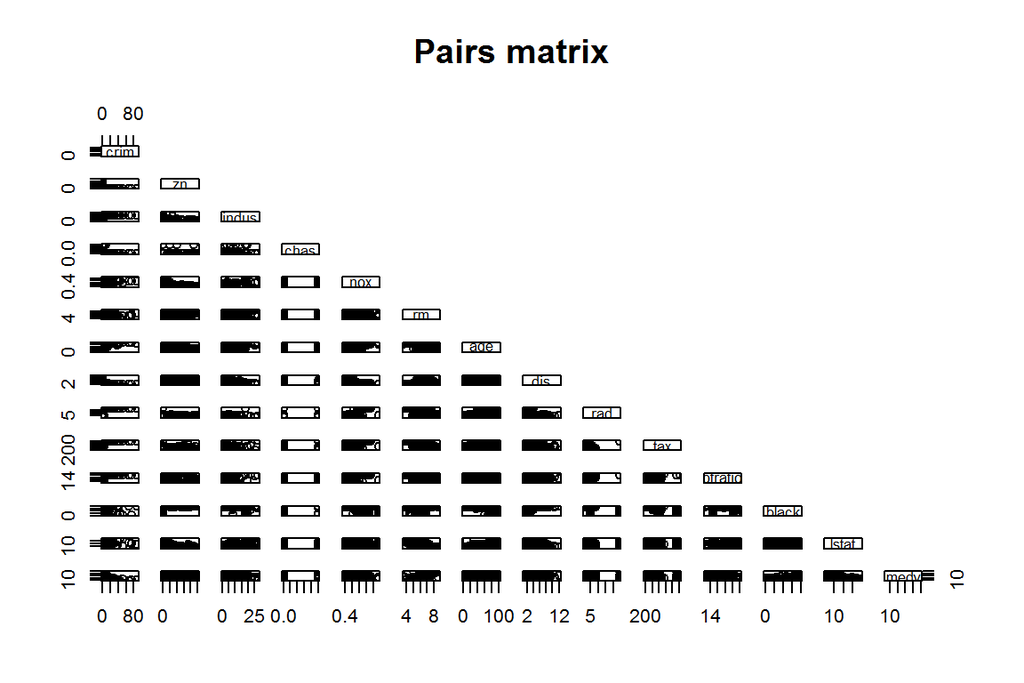

```r
pairs(Boston, main = "Pairs matrix", upper.panel = NULL)
```

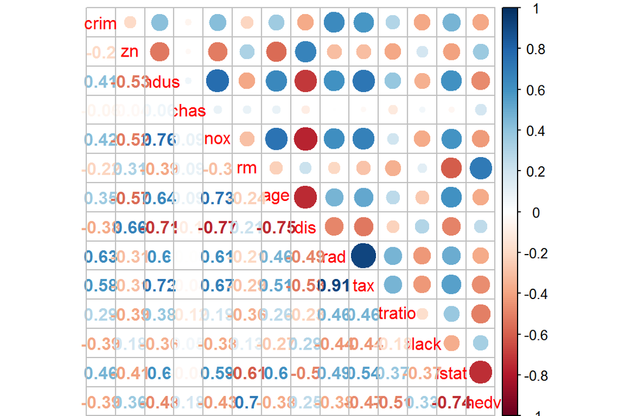

```r
cor_matrix<-cor(Boston) %>% round(digits = 2)
corrplot.mixed(cor_matrix)
```

## Scaling of data

The summaries bellow show smallest, highes and mean values of the variables, in addition to other data. It can be seen that the variable data is using very different scales.

```r
summary(Boston)
```

```
##       crim                zn             indus            chas
##  Min.   : 0.00632   Min.   :  0.00   Min.   : 0.46   Min.   :0.00000
##  1st Qu.: 0.08204   1st Qu.:  0.00   1st Qu.: 5.19   1st Qu.:0.00000
##  Median : 0.25651   Median :  0.00   Median : 9.69   Median :0.00000
##  Mean   : 3.61352   Mean   : 11.36   Mean   :11.14   Mean   :0.06917
##  3rd Qu.: 3.67708   3rd Qu.: 12.50   3rd Qu.:18.10   3rd Qu.:0.00000
##  Max.   :88.97620   Max.   :100.00   Max.   :27.74   Max.   :1.00000
##       nox               rm             age              dis
##  Min.   :0.3850   Min.   :3.561   Min.   :  2.90   Min.   : 1.130
##  1st Qu.:0.4490   1st Qu.:5.886   1st Qu.: 45.02   1st Qu.: 2.100
##  Median :0.5380   Median :6.208   Median : 77.50   Median : 3.207
##  Mean   :0.5547   Mean   :6.285   Mean   : 68.57   Mean   : 3.795
##  3rd Qu.:0.6240   3rd Qu.:6.623   3rd Qu.: 94.08   3rd Qu.: 5.188
##  Max.   :0.8710   Max.   :8.780   Max.   :100.00   Max.   :12.127
##       rad              tax           ptratio          black
##  Min.   : 1.000   Min.   :187.0   Min.   :12.60   Min.   :  0.32
##  1st Qu.: 4.000   1st Qu.:279.0   1st Qu.:17.40   1st Qu.:375.38
##  Median : 5.000   Median :330.0   Median :19.05   Median :391.44
##  Mean   : 9.549   Mean   :408.2   Mean   :18.46   Mean   :356.67
##  3rd Qu.:24.000   3rd Qu.:666.0   3rd Qu.:20.20   3rd Qu.:396.23
##  Max.   :24.000   Max.   :711.0   Max.   :22.00   Max.   :396.90
##      lstat            medv
##  Min.   : 1.73   Min.   : 5.00
##  1st Qu.: 6.95   1st Qu.:17.02
##  Median :11.36   Median :21.20
##  Mean   :12.65   Mean   :22.53
##  3rd Qu.:16.95   3rd Qu.:25.00
##  Max.   :37.97   Max.   :50.00
```

Since the range of values in the data is quite different and broad, it should be scaled, in order to be able to compare the data and make sure that all the variables contribute proportionally.

```r
boston_scaled <- scale(Boston)
summary(boston_scaled)
```

```
##       crim                 zn               indus
##  Min.   :-0.419367   Min.   :-0.48724   Min.   :-1.5563
##  1st Qu.:-0.410563   1st Qu.:-0.48724   1st Qu.:-0.8668
##  Median :-0.390280   Median :-0.48724   Median :-0.2109
##  Mean   : 0.000000   Mean   : 0.00000   Mean   : 0.0000
##  3rd Qu.: 0.007389   3rd Qu.: 0.04872   3rd Qu.: 1.0150
##  Max.   : 9.924110   Max.   : 3.80047   Max.   : 2.4202
##       chas              nox                rm               age
##  Min.   :-0.2723   Min.   :-1.4644   Min.   :-3.8764   Min.   :-2.3331
##  1st Qu.:-0.2723   1st Qu.:-0.9121   1st Qu.:-0.5681   1st Qu.:-0.8366
##  Median :-0.2723   Median :-0.1441   Median :-0.1084   Median : 0.3171
##  Mean   : 0.0000   Mean   : 0.0000   Mean   : 0.0000   Mean   : 0.0000
##  3rd Qu.:-0.2723   3rd Qu.: 0.5981   3rd Qu.: 0.4823   3rd Qu.: 0.9059
##  Max.   : 3.6648   Max.   : 2.7296   Max.   : 3.5515   Max.   : 1.1164
##       dis               rad               tax             ptratio
##  Min.   :-1.2658   Min.   :-0.9819   Min.   :-1.3127   Min.   :-2.7047
##  1st Qu.:-0.8049   1st Qu.:-0.6373   1st Qu.:-0.7668   1st Qu.:-0.4876
##  Median :-0.2790   Median :-0.5225   Median :-0.4642   Median : 0.2746
##  Mean   : 0.0000   Mean   : 0.0000   Mean   : 0.0000   Mean   : 0.0000
##  3rd Qu.: 0.6617   3rd Qu.: 1.6596   3rd Qu.: 1.5294   3rd Qu.: 0.8058
##  Max.   : 3.9566   Max.   : 1.6596   Max.   : 1.7964   Max.   : 1.6372
##      black             lstat              medv
##  Min.   :-3.9033   Min.   :-1.5296   Min.   :-1.9063
##  1st Qu.: 0.2049   1st Qu.:-0.7986   1st Qu.:-0.5989
##  Median : 0.3808   Median :-0.1811   Median :-0.1449
##  Mean   : 0.0000   Mean   : 0.0000   Mean   : 0.0000
##  3rd Qu.: 0.4332   3rd Qu.: 0.6024   3rd Qu.: 0.2683
##  Max.   : 0.4406   Max.   : 3.5453   Max.   : 2.9865
```

```r
boston_scaled <- as.data.frame(boston_scaled)
```

Now that the data is scaled, the ranges look similar. Note that the means are all zero.

## Categorical variable

It is possible to create a categorical variable from a continuous one. This will be done with *crim* (per vapita crime rate by town) variable. *crim* will be the so-called **factor variable**. It will be cut by quantiles to get the **high**, **low** and **middle** rates of crime into their categories.

```r
scaled_crim <- c(boston_scaled$crim)
summary(scaled_crim)
```

```
##      Min.   1st Qu.    Median      Mean   3rd Qu.      Max.
## -0.419400 -0.410600 -0.390300  0.000000  0.007389  9.924000
```

```r
bins <- quantile(scaled_crim)
crime <- cut(scaled_crim, breaks = bins, include.lowest = TRUE, label = c("low", "med_low", "med_high", "high"))
table(crime)
```

```
## crime
##      low  med_low med_high     high
##      127      126      126      127
```

We can see that now *crime* data has been split into 4 categories. The original *crim* variable will be removed from the dataset and the new one *crime* will be added instead.

```r
boston_scaled <- dplyr::select(boston_scaled, -crim)
boston_scaled <- data.frame(boston_scaled, crime)
```

## Dividing of data and LDA

When using statistical methods to predict something, it is important to split the data to train and test sets and see how the model works (well or poorly). The train set is used to train the model and the test set is used to make predictions on data.

The data will be divided to these two sets, so that 80% of it would belong to the train set:

```r
n <- nrow(boston_scaled)
ind <- sample(n,  size = n * 0.8)
train <- boston_scaled[ind,]
test <- boston_scaled[-ind,]
```

Now the linear discriminant analysis (LDA) will be fitten on the train set. The new categorical crime rate will be the target variable and all the other variables in the dataset will be used as predictor variables.

```r
lda.fit <- lda(crime ~ ., data = train)
lda.fit
```

```
## Call:
## lda(crime ~ ., data = train)
##
## Prior probabilities of groups:
##       low   med_low  med_high      high
## 0.2648515 0.2500000 0.2500000 0.2351485
##
## Group means:
##                   zn      indus        chas        nox         rm
## low       0.94573776 -0.9268825 -0.08835242 -0.8668238  0.4347713
## med_low  -0.02769068 -0.3122471 -0.03844192 -0.5941056 -0.1327720
## med_high -0.38365582  0.1937743  0.27340760  0.4063519  0.1658710
## high     -0.48724019  1.0172655 -0.02367011  1.0656400 -0.4025291
##                 age        dis        rad        tax     ptratio
## low      -0.8723364  0.8759526 -0.6899244 -0.7481851 -0.49921221
## med_low  -0.3948826  0.4675513 -0.5349924 -0.4896505 -0.06635382
## med_high  0.4803792 -0.4041378 -0.3985409 -0.3020725 -0.36727832
## high      0.8142367 -0.8468310  1.6366336  1.5129868  0.77903654
##                black       lstat        medv
## low       0.37595840 -0.76114730  0.51894608
## med_low   0.31231006 -0.13282462 -0.02434412
## med_high  0.05657902  0.02298881  0.19483809
## high     -0.67793668  0.90209055 -0.72106977
##
## Coefficients of linear discriminants:
##                 LD1         LD2         LD3
## zn       0.11679677  0.64961197 -0.98914959
## indus    0.04007212 -0.26883368  0.47568983
## chas    -0.05863702 -0.08352713  0.03456193
## nox      0.37896833 -0.69199521 -1.08852690
## rm      -0.12313114 -0.10340288 -0.10964001
## age      0.22909018 -0.44397592 -0.16753398
## dis     -0.08086468 -0.31559152  0.42802675
## rad      3.08755623  0.92484854 -0.03552045
## tax      0.08527416 -0.01372707  0.32706971
## ptratio  0.10233362  0.06498406 -0.19734050
## black   -0.11857686  0.06132042  0.16915426
## lstat    0.19615606 -0.16888364  0.40468783
## medv     0.16774786 -0.40001850 -0.14367565
##
## Proportion of trace:
##    LD1    LD2    LD3
## 0.9453 0.0413 0.0133
```

```r
lda.arrows <- function(x, myscale = 1, arrow_heads = 0.1, color = "red", tex = 0.75, choices = c(1,2)){
  heads <- coef(x)
  arrows(x0 = 0, y0 = 0,
         x1 = myscale * heads[,choices[1]],
         y1 = myscale * heads[,choices[2]], col=color, length = arrow_heads)
  text(myscale * heads[,choices], labels = row.names(heads),
       cex = tex, col=color, pos=3)
}
classes <- as.numeric(train$crime)
```

The scatterplot of the LDA below shows that variable *rad* (index of accessibility to radial highways) is mostly linked with the high crime rates that are in the plot in colour blue. The remaining crime categories are scattered away from the high crime rate category and it’s quite hard to see which variables are associated with which categories. Maybe it’s quite safe to say that *nox* (nitrogen oxides concentration (parts per 10 million)) is associated with medium high crime rates that are in colour green.

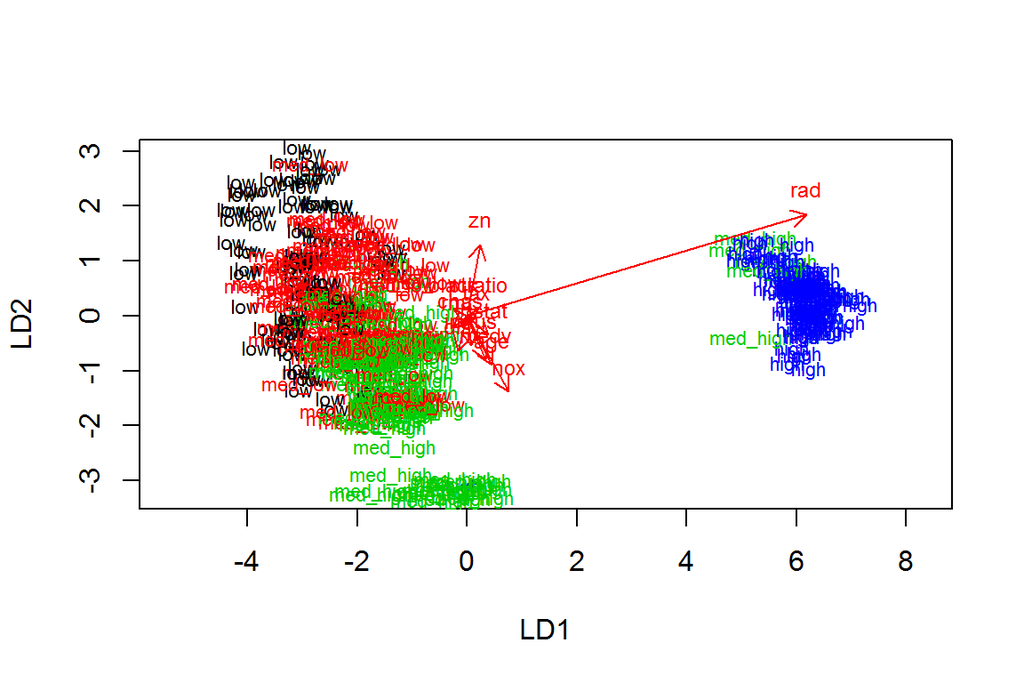

```r
plot(lda.fit, dimen = 2, col = classes, pch = classes)
lda.arrows(lda.fit, myscale = 2)
```

The crime categories from the test set will be saved and the categorical crime variable will be removed from the dataset. This will allow us to predict the classes with the LDA model on the test data.

```r
correct_classes <- test$crime
test <- dplyr::select(test, -crime)
```

Now the classes will be predecited with the LDA model on the test data.

```r
lda.pred <- predict(lda.fit, newdata = test)
```

The results are cross tabulated below with the crime categories from the test set.

```r
table(correct = correct_classes, predicted = lda.pred$class)
```

```
##           predicted
## correct    low med_low med_high high
##   low       12       8        0    0
##   med_low    5      15        5    0
##   med_high   1      11       12    1
##   high       0       0        0   32
```

*Note: the values in the cross tabulation will change every time the page is refreshed because it takes random observations to the test and train sets. Thus, the explanation bellow probably will not have relevant numbers.*

## Clustering

The clustering will be done with the k-means method.

```r
data("Boston")
```

```r
boston_scaled <- scale(Boston)
summary(boston_scaled)
```

```
##       crim                 zn               indus
##  Min.   :-0.419367   Min.   :-0.48724   Min.   :-1.5563
##  1st Qu.:-0.410563   1st Qu.:-0.48724   1st Qu.:-0.8668
##  Median :-0.390280   Median :-0.48724   Median :-0.2109
##  Mean   : 0.000000   Mean   : 0.00000   Mean   : 0.0000
##  3rd Qu.: 0.007389   3rd Qu.: 0.04872   3rd Qu.: 1.0150
##  Max.   : 9.924110   Max.   : 3.80047   Max.   : 2.4202
##       chas              nox                rm               age
##  Min.   :-0.2723   Min.   :-1.4644   Min.   :-3.8764   Min.   :-2.3331
##  1st Qu.:-0.2723   1st Qu.:-0.9121   1st Qu.:-0.5681   1st Qu.:-0.8366
##  Median :-0.2723   Median :-0.1441   Median :-0.1084   Median : 0.3171
##  Mean   : 0.0000   Mean   : 0.0000   Mean   : 0.0000   Mean   : 0.0000
##  3rd Qu.:-0.2723   3rd Qu.: 0.5981   3rd Qu.: 0.4823   3rd Qu.: 0.9059
##  Max.   : 3.6648   Max.   : 2.7296   Max.   : 3.5515   Max.   : 1.1164
##       dis               rad               tax             ptratio
##  Min.   :-1.2658   Min.   :-0.9819   Min.   :-1.3127   Min.   :-2.7047
##  1st Qu.:-0.8049   1st Qu.:-0.6373   1st Qu.:-0.7668   1st Qu.:-0.4876
##  Median :-0.2790   Median :-0.5225   Median :-0.4642   Median : 0.2746
##  Mean   : 0.0000   Mean   : 0.0000   Mean   : 0.0000   Mean   : 0.0000
##  3rd Qu.: 0.6617   3rd Qu.: 1.6596   3rd Qu.: 1.5294   3rd Qu.: 0.8058
##  Max.   : 3.9566   Max.   : 1.6596   Max.   : 1.7964   Max.   : 1.6372
##      black             lstat              medv
##  Min.   :-3.9033   Min.   :-1.5296   Min.   :-1.9063
##  1st Qu.: 0.2049   1st Qu.:-0.7986   1st Qu.:-0.5989
##  Median : 0.3808   Median :-0.1811   Median :-0.1449
##  Mean   : 0.0000   Mean   : 0.0000   Mean   : 0.0000
##  3rd Qu.: 0.4332   3rd Qu.: 0.6024   3rd Qu.: 0.2683
##  Max.   : 0.4406   Max.   : 3.5453   Max.   : 2.9865
```

```r
boston_scaled <- as.data.frame(boston_scaled)
```

Clustering is done based on distances between the objects. Bellow there is a summary of distances for the scaled Boston dataset.

```r
set.seed(123)
dist_eu <- dist(boston_scaled)
summary(dist_eu)
```

```
##    Min. 1st Qu.  Median    Mean 3rd Qu.    Max.
##  0.1343  3.4620  4.8240  4.9110  6.1860 14.4000
```

In order to determine the correct number of clusters the **Elbow method** will be used which is based on the calculation of the total of within cluster sum of squares (WCSS).

```r
k_max <- 10
```

```r
twcss <- sapply(1:k_max, function(k){kmeans(dist_eu, k)$tot.withinss})
```

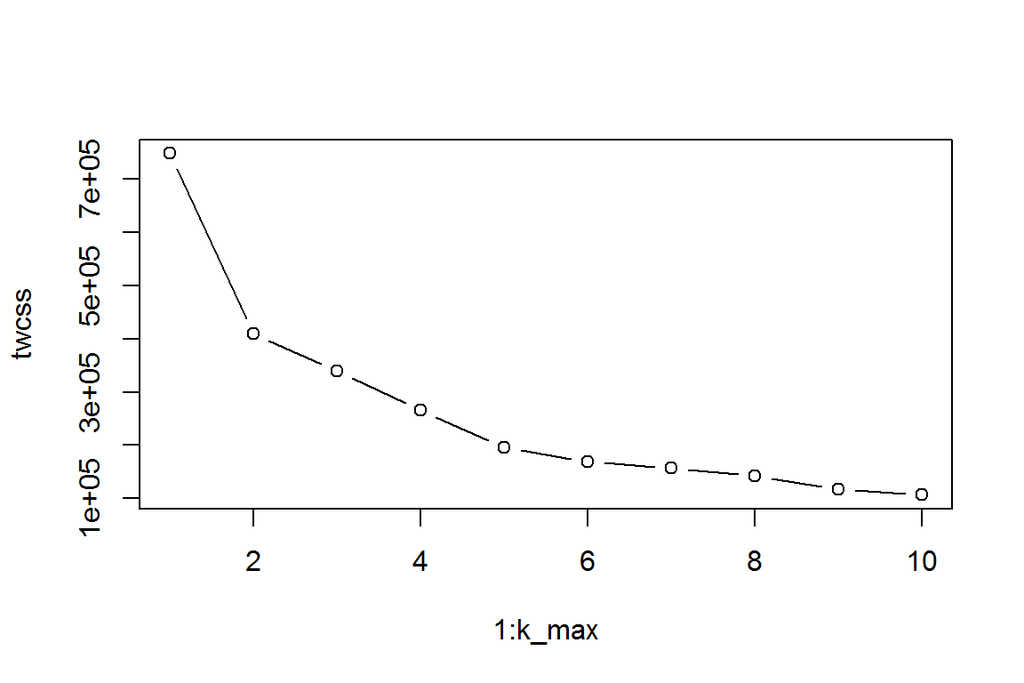

```r
plot(1:k_max, twcss, type = 'b')
```

In the grapgh above we can see that the value drops significantly from 1 to 2 and after that in decreases steadily. That shows us that the optimal number of clusters is 2. Thus the clustering will be done with 2 clusters.

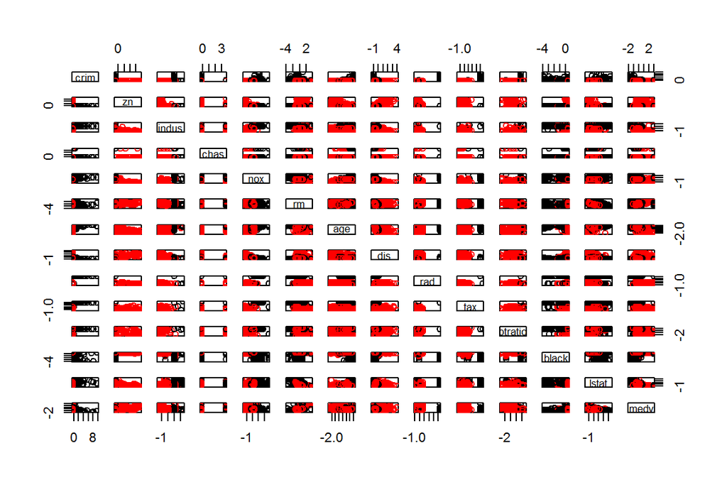

```r
km <- kmeans(dist_eu, centers = 2)
pairs(boston_scaled, col = km$cluster)
```

The plot above shows that the distributiosn of variables are almost the same as those that were examined in the begining of this chapter. The colours indicate different clusters and in many plots it is quite easy to see how those clusters are separating the data.

# Dimensionality reduction techniques

## The Data

The dataset originates from the United Nations Development Programme. The data has been mutated and now it contains 155 observations and 8 variables in the dataset. The variables in the dataset are listed below.

```r
setwd("C:/Users/Severi/Documents/Open Data/IODS-project/data")
library(MASS)
library(dplyr)
library('corrplot')
library(GGally)
library(tidyr)
library(ggplot2)
human_ <- read.table(file = "human2.txt", sep = ";")
```

```r
str(human_)
```

```
## 'data.frame':    155 obs. of  8 variables:
##  $ edu2FM   : num  1.007 0.997 0.983 0.989 0.969 ...
##  $ labF     : num  61.2 58.8 61.8 58.7 58.5 53.6 53.1 56.3 61.6 62 ...
##  $ lifeexp  : num  81.6 82.4 83 80.2 81.6 80.9 80.9 79.1 82 81.8 ...
##  $ eduexp   : num  17.5 20.2 15.8 18.7 17.9 16.5 18.6 16.5 15.9 19.2 ...
##  $ gni      : int  64992 42261 56431 44025 45435 43919 39568 52947 42155 32689 ...
##  $ matmort  : int  4 6 6 5 6 7 9 28 11 8 ...
##  $ adolbirth: num  7.8 12.1 1.9 5.1 6.2 3.8 8.2 31 14.5 25.3 ...
##  $ repparl  : num  39.6 30.5 28.5 38 36.9 36.9 19.9 19.4 28.2 31.4 ...
```

```r
dim(human_)
```

```
## [1] 155   8
```

- *edu2FM* - Female/male ratio in secondary education
- *labF* - Proportion of females in the labour force
- *lifeexp* - Life expectancy at birth
- *eduexp* - Expected years of schooling
- *gni* - Gross National Income per capita
- *matmort* - Maternal mortality ratio
- *adolbirth* - Adolescent birth rate
- *repparl* - Percetange of female representatives in parliament

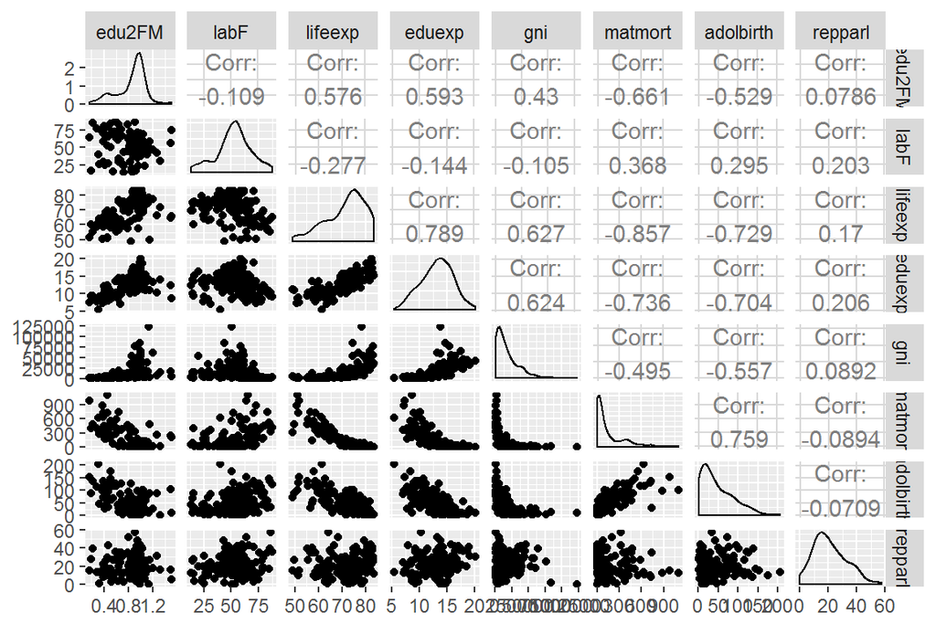

```r
ggpairs(human_)
```

The correlation plot shows strong negative correlation between the previously mentioned variables: *lifeexp* and *matmort*. Also strong negative correlation is between *lifeexp*-*adolbirth*, *eduexp*-*matmort*, and *eduexp*-*adolbirth*. Strong positive correlation is noticable between *lifeexp*-*eduexp* and *marmort*-*adolbirth*.

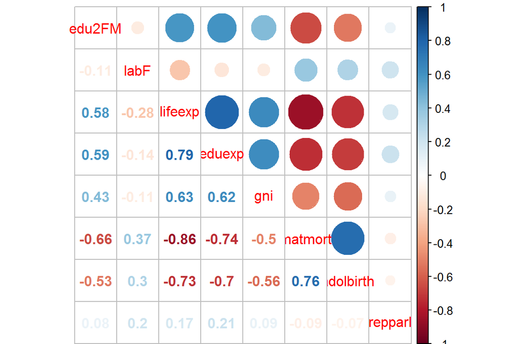

```r
cor_matrix<-cor(human_) %>% round(digits = 2)
corrplot.mixed(cor_matrix)
```

The summaries of the variables are below. The female/male ratio in secondary education (*edu2FM*) on average is about 0.85. Proportion of females in the labour force (*labF*) ranges from 13.5 to 88.1 with average of 52.5. Gross National Income per capita (*gni*) range is really big (from 581 to 123124). Interestingly, our data shows that some Parliaments have no women representatives.

```r
summary(human_)
```

```
##      edu2FM            labF          lifeexp          eduexp
##  Min.   :0.1717   Min.   :13.50   Min.   :49.00   Min.   : 5.40
##  1st Qu.:0.7264   1st Qu.:44.45   1st Qu.:66.30   1st Qu.:11.25
##  Median :0.9375   Median :53.50   Median :74.20   Median :13.50
##  Mean   :0.8529   Mean   :52.52   Mean   :71.65   Mean   :13.18
##  3rd Qu.:0.9968   3rd Qu.:61.90   3rd Qu.:77.25   3rd Qu.:15.20
##  Max.   :1.4967   Max.   :88.10   Max.   :83.50   Max.   :20.20
##       gni            matmort         adolbirth         repparl
##  Min.   :   581   Min.   :   1.0   Min.   :  0.60   Min.   : 0.00
##  1st Qu.:  4198   1st Qu.:  11.5   1st Qu.: 12.65   1st Qu.:12.40
##  Median : 12040   Median :  49.0   Median : 33.60   Median :19.30
##  Mean   : 17628   Mean   : 149.1   Mean   : 47.16   Mean   :20.91
##  3rd Qu.: 24512   3rd Qu.: 190.0   3rd Qu.: 71.95   3rd Qu.:27.95
##  Max.   :123124   Max.   :1100.0   Max.   :204.80   Max.   :57.50
```

## Principal Component Analysis (PCA)

```r
pca_human <- prcomp(human_)
summary(pca_human)
```

```
## Importance of components:
##                              PC1      PC2   PC3   PC4   PC5   PC6   PC7
## Standard deviation     1.854e+04 185.6147 25.21 15.38 10.68 3.766 1.546
## Proportion of Variance 9.999e-01   0.0001  0.00  0.00  0.00 0.000 0.000
## Cumulative Proportion  9.999e-01   1.0000  1.00  1.00  1.00 1.000 1.000
##                           PC8
## Standard deviation     0.1734
## Proportion of Variance 0.0000
## Cumulative Proportion  1.0000
```

The same goes for the biplot below which clearly indicates that *gni* has much bigger scale than all the other variables.

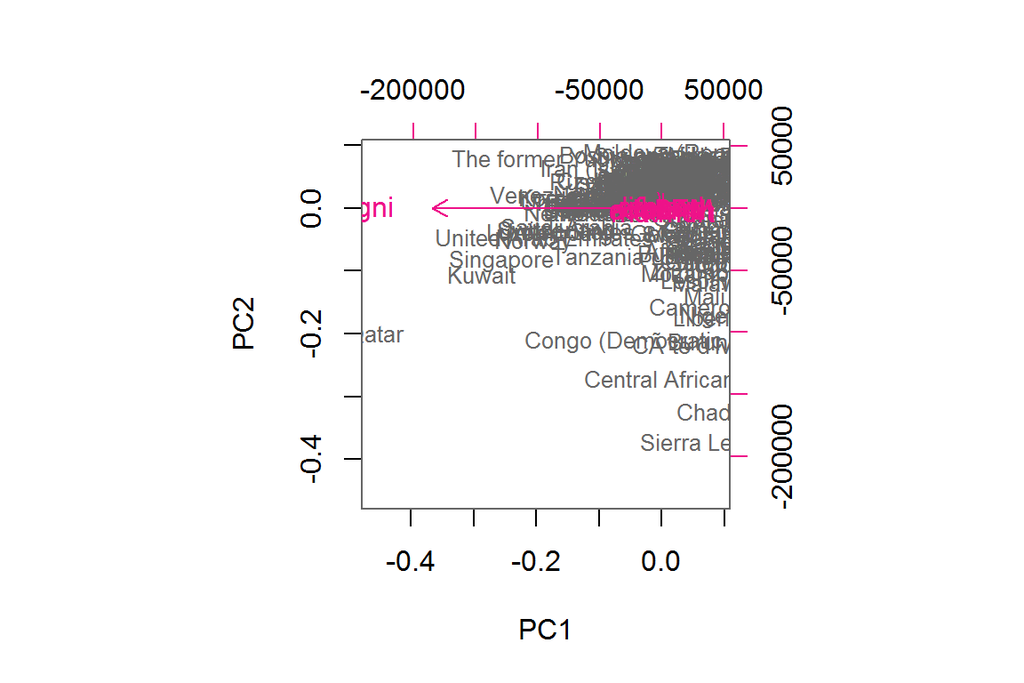

```r
biplot(pca_human, choices = 1:2, cex = c(0.8, 1), col = c("grey40", "deeppink2"))
```

The data will, therefore, be standartized.

The summary of variables now shows that the scale is now more similar between different variables, thus the PCA can now be performed again.

```r
human_std <- scale(human_)
summary(human_std)
```

```
##      edu2FM             labF             lifeexp            eduexp
##  Min.   :-2.8189   Min.   :-2.43186   Min.   :-2.7188   Min.   :-2.7378
##  1st Qu.:-0.5233   1st Qu.:-0.50289   1st Qu.:-0.6425   1st Qu.:-0.6782
##  Median : 0.3503   Median : 0.06116   Median : 0.3056   Median : 0.1140
##  Mean   : 0.0000   Mean   : 0.00000   Mean   : 0.0000   Mean   : 0.0000
##  3rd Qu.: 0.5958   3rd Qu.: 0.58469   3rd Qu.: 0.6717   3rd Qu.: 0.7126
##  Max.   : 2.6646   Max.   : 2.21762   Max.   : 1.4218   Max.   : 2.4730
##       gni             matmort          adolbirth          repparl
##  Min.   :-0.9193   Min.   :-0.6992   Min.   :-1.1325   Min.   :-1.8203
##  1st Qu.:-0.7243   1st Qu.:-0.6496   1st Qu.:-0.8394   1st Qu.:-0.7409
##  Median :-0.3013   Median :-0.4726   Median :-0.3298   Median :-0.1403
##  Mean   : 0.0000   Mean   : 0.0000   Mean   : 0.0000   Mean   : 0.0000
##  3rd Qu.: 0.3712   3rd Qu.: 0.1932   3rd Qu.: 0.6030   3rd Qu.: 0.6127
##  Max.   : 5.6890   Max.   : 4.4899   Max.   : 3.8344   Max.   : 3.1850
```

The summary shows that now 2 first components explain about 70% of variance, thus the results of the PCA are much better after the data has been standartized.

```r
pca_human2 <- prcomp(human_std)
summary(pca_human2)
```

```
## Importance of components:
##                           PC1    PC2     PC3     PC4     PC5     PC6
## Standard deviation     2.0884 1.1132 0.87196 0.77712 0.64106 0.53726
## Proportion of Variance 0.5452 0.1549 0.09504 0.07549 0.05137 0.03608
## Cumulative Proportion  0.5452 0.7001 0.79512 0.87061 0.92198 0.95806
##                           PC7     PC8
## Standard deviation     0.4800 0.32430
## Proportion of Variance 0.0288 0.01315
## Cumulative Proportion  0.9869 1.00000
```

The biplot shows high correlation between *matmort* and *adolbirth*. In addition to that the variables *gni*, *eduexp*, *edu2FM* and *lifeexp* seems to be correlated with each other as well. *repparl* is mostly correlated with *labF*; other variables have low/no correlation with *repparl*.

It looks like *matmort*, *adolbirth*, *gni*, *eduexp*, *edu2FM* and *lifeexp* contribute to the dimension of the PC1, while *repparl* and *labF* best define PC2.

The variables that define PC1 are clearly devided into two groups.One group of variables consists of *eduexp* (expected years of schooling), *gni* (Gross National Income per capita), *edu2FM* (female/male ratio in secondary education), and *lifeexp* (life expectancy at birth). The other group defining PC1 contains *matmort* (maternal mortality ratio) and *adolbirth* (adolescent birth rate). These groups together explain education, health and general wealth phenomenons.

The second principal component that is defined by *repparl* (percentage of female representatives in the parliament) and *labF* (proportion of females in the labour force) explains the gender diversity phenomenon.

The plot indicates that such countries as, e.g. Iceland, Norway, Sweden, Denmank have not only high gross national income per capita but also are high in gender diversity and life expentancy. Whereas, Saudi Arabia, Qatar, Bahrain are high in GNI, but don’t have a good situation in gender diversity issues. Countries in Africa seem to have high mortality, poor education and low income.

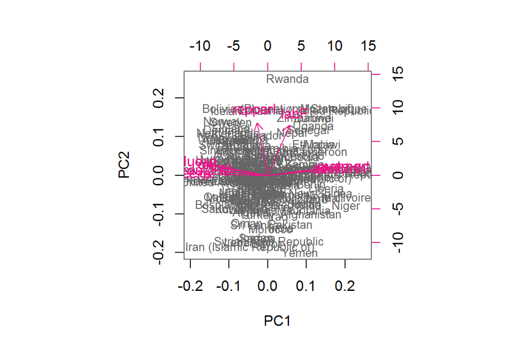

```r
biplot(pca_human2, choices = 1:2, cex = c(0.8, 1), col = c("grey40", "deeppink2"))
```

## Tea dataset

New dataset is now loaded. It is related to tea consumption. The data has 300 observations and 36 variables.

```r
library(FactoMineR)
data("tea")
dim(tea)
```

```
## [1] 300  36
```

It seems that the variables are related to the time people drink their tea, the places where they drink, how and why they drink it and some other information.

```r
str(tea)
```

```
## 'data.frame':    300 obs. of  36 variables:
##  $ breakfast       : Factor w/ 2 levels "breakfast","Not.breakfast": 1 1 2 2 1 2 1 2 1 1 ...
##  $ tea.time        : Factor w/ 2 levels "Not.tea time",..: 1 1 2 1 1 1 2 2 2 1 ...
##  $ evening         : Factor w/ 2 levels "evening","Not.evening": 2 2 1 2 1 2 2 1 2 1 ...
##  $ lunch           : Factor w/ 2 levels "lunch","Not.lunch": 2 2 2 2 2 2 2 2 2 2 ...
##  $ dinner          : Factor w/ 2 levels "dinner","Not.dinner": 2 2 1 1 2 1 2 2 2 2 ...
##  $ always          : Factor w/ 2 levels "always","Not.always": 2 2 2 2 1 2 2 2 2 2 ...
##  $ home            : Factor w/ 2 levels "home","Not.home": 1 1 1 1 1 1 1 1 1 1 ...
##  $ work            : Factor w/ 2 levels "Not.work","work": 1 1 2 1 1 1 1 1 1 1 ...
##  $ tearoom         : Factor w/ 2 levels "Not.tearoom",..: 1 1 1 1 1 1 1 1 1 2 ...
##  $ friends         : Factor w/ 2 levels "friends","Not.friends": 2 2 1 2 2 2 1 2 2 2 ...
##  $ resto           : Factor w/ 2 levels "Not.resto","resto": 1 1 2 1 1 1 1 1 1 1 ...
##  $ pub             : Factor w/ 2 levels "Not.pub","pub": 1 1 1 1 1 1 1 1 1 1 ...
##  $ Tea             : Factor w/ 3 levels "black","Earl Grey",..: 1 1 2 2 2 2 2 1 2 1 ...
##  $ How             : Factor w/ 4 levels "alone","lemon",..: 1 3 1 1 1 1 1 3 3 1 ...
```

[output cut: 22 more lines]

Only the variables realted to type of tea, way of drinking, frequency of drinking tea and wheather or not tea drinking is feminine or spiritual will be analysed. Their summaries are below.

```r
keep_columns <- c("Tea", "How", "how", "feminine", "frequency", "spirituality")
tea_time <- dplyr::select(tea, one_of(keep_columns))
summary(tea_time)
```

```
##         Tea         How                      how              feminine
##  black    : 74   alone:195   tea bag           :170   feminine    :129
##  Earl Grey:193   lemon: 33   tea bag+unpackaged: 94   Not.feminine:171
##  green    : 33   milk : 63   unpackaged        : 36
##                  other:  9
##        frequency             spirituality
##  1/day      : 95   Not.spirituality:206
##  1 to 2/week: 44   spirituality    : 94
##  +2/day     :127
##  3 to 6/week: 34
```

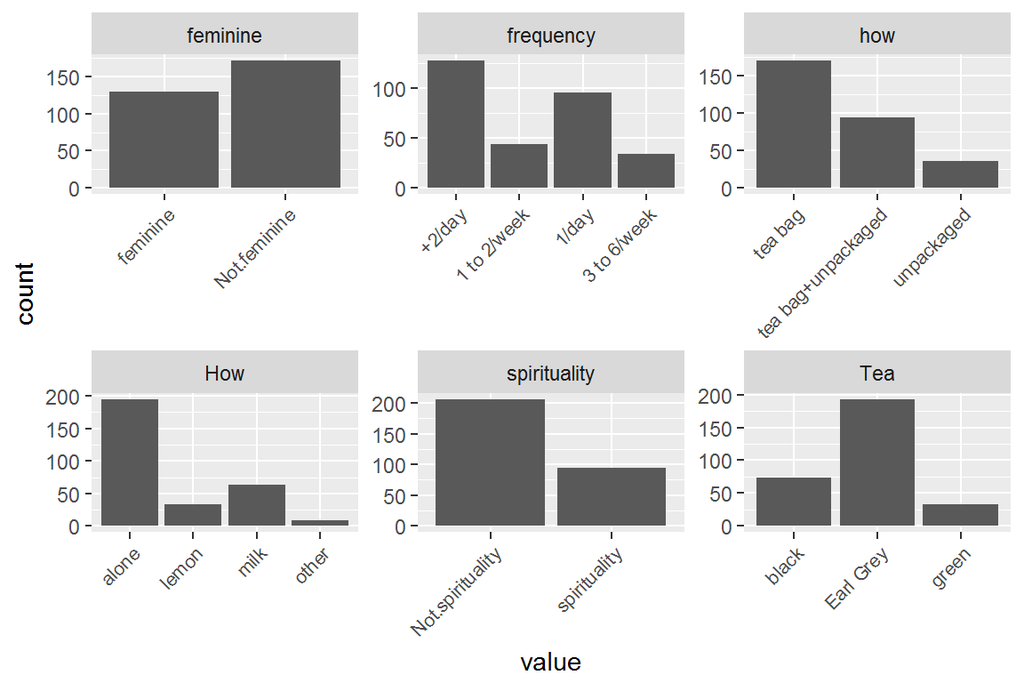

```r
gather(tea_time) %>% ggplot(aes(value)) + facet_wrap("key", scales = "free") + geom_bar() + theme(axis.text.x = element_text(angle = 45, hjust = 1, size = 8))
```

There are 12 dimensions based on the summary below.

```r
mca <- MCA(tea_time, graph = FALSE)
summary(mca)
```

```
##
## Call:
## MCA(X = tea_time, graph = FALSE)
##
##
## Eigenvalues
##                        Dim.1   Dim.2   Dim.3   Dim.4   Dim.5   Dim.6
## Variance               0.222   0.210   0.200   0.193   0.179   0.168
## % of var.             11.096  10.509  10.001   9.640   8.973   8.402
## Cumulative % of var.  11.096  21.605  31.605  41.245  50.218  58.620
##                        Dim.7   Dim.8   Dim.9  Dim.10  Dim.11  Dim.12
## Variance               0.165   0.159   0.143   0.138   0.112   0.111
## % of var.              8.253   7.953   7.156   6.904   5.586   5.528
## Cumulative % of var.  66.873  74.826  81.982  88.886  94.472 100.000
##
## Individuals (the 10 first)
##                       Dim.1    ctr   cos2    Dim.2    ctr   cos2    Dim.3
## 1                  |  0.247  0.092  0.047 | -0.717  0.815  0.399 | -0.202
## 2                  |  0.161  0.039  0.014 | -1.130  2.027  0.700 |  0.153
## 3                  | -0.041  0.002  0.002 | -0.085  0.011  0.010 | -0.040
## 4                  | -0.615  0.567  0.326 | -0.198  0.062  0.034 | -0.044
## 5                  | -0.291  0.127  0.082 |  0.267  0.113  0.069 |  0.177
## 6                  | -0.364  0.199  0.152 | -0.549  0.478  0.346 | -0.261
## 7                  |  0.062  0.006  0.002 | -0.113  0.020  0.007 | -0.565
## 8                  |  0.161  0.039  0.010 | -0.289  0.133  0.033 | -0.038
## 9                  |  0.100  0.015  0.007 | -0.383  0.232  0.097 |  0.588
## 10                 |  0.798  0.957  0.457 | -0.137  0.030  0.013 |  0.292
##                       ctr   cos2
## 1                   0.068  0.032 |
## 2                   0.039  0.013 |
## 3                   0.003  0.002 |
## 4                   0.003  0.002 |
## 5                   0.052  0.030 |
## 6                   0.114  0.078 |
## 7                   0.532  0.176 |
## 8                   0.002  0.001 |
## 9                   0.575  0.228 |
## 10                  0.142  0.061 |
##
## Categories (the 10 first)
```

[output cut: 16 more lines]

```
## lemon                0.114   5.836 |   0.236   0.513   0.007   1.438 |
## milk                 0.252  -8.688 |   0.596   6.217   0.094   5.314 |
## other                0.002  -0.722 |   2.678  17.926   0.222   8.143 |
## tea bag              0.053  -3.974 |  -0.090   0.386   0.011  -1.787 |
## tea bag+unpackaged   0.006   1.367 |   0.641  10.734   0.188   7.489 |
## unpackaged           0.056   4.108 |  -1.247  15.561   0.212  -7.966 |
##
## Categorical variables (eta2)
##                      Dim.1 Dim.2 Dim.3
## Tea                | 0.536 0.041 0.116 |
## How                | 0.138 0.320 0.378 |
## how                | 0.310 0.077 0.320 |
## feminine           | 0.036 0.279 0.012 |
## frequency          | 0.204 0.343 0.301 |
## spirituality       | 0.108 0.201 0.073 |
```

The MCA factor map shows that people who preffer drinking tea alone, like it to be Earl Grey or green. It seems that those who view tea drinking as non spiritual also think it’s not a feminine activity, while those who associate it with femininity also think it’s spiritual.

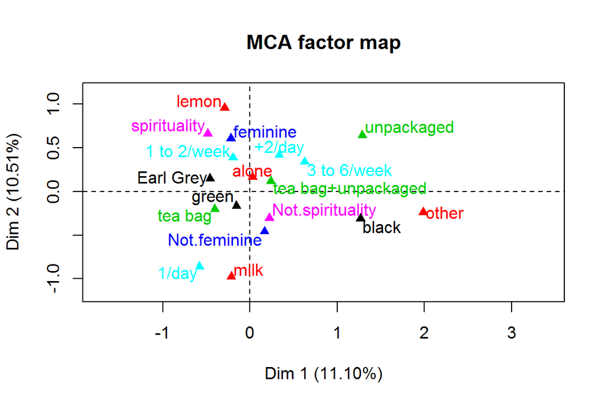

```r
plot(mca, invisible = c("ind"), habillage = "quali")
```